# *[Registro de Vertimientos al suelo de los usuarios del recurso hídrico en la jurisdicción de Corantioquia periodo 2020-2026](https://www.datos.gov.co/Ambiente-y-Desarrollo-Sostenible/Registro-de-vertimientos-al-suelo/e5yb-6ae7/about_data)*

Mateo Vallejo

Melliza Paternina

Esteban Avendaño Del Toro

Manuela Cano

Jennifer Caicedo Sanmartín

2026-05-08

Registro de vertimientos al suelo de los usuarios del recurso hídrico en la jurisdicción de Corantioquia. https://www.datos.gov.co/Ambiente-y-Desarrollo-Sostenible/Registro-de-vertimientos-al-suelo/e5yb-6ae7/about_data.

## *Ficha Técnica*

| Concepto | Descripción |
| --- | --- |
| **Población** | Vertimientos al suelo de los usuarios del recurso hídrico en la jurisdicción de Corantioquia periodo 2020-2026 |
| **Tamaño de la población** | 7129 vertimientos |
| **Cobertura** | Periodo 2020-2026 |
| **Variable Aleatoria de Rigor o de Peso** | Caudal |
| **Nivel de confianza** | 95%. Nivel de confianza utilizado para que los intervalos estimados representen adecuadamente el comportamiento poblacional del caudal |
| **Error de muestreo** | 10%. Margen de error permitido en la estimación de los parámetros de interés asociados a la variable Caudal. |
| **Tamaño de muestra** | 85 vertimientos seleccionados a partir de la población total de 7129 registros. |
| **Técnica de muestreo** | Muestreo por Hipercubo Latino (Latin Hypercube Sampling - LHS), aplicado sobre la variable continua *Caudal* con el fin de garantizar una representación homogénea de todo el rango de variación de la v… |

La gran mayoría de los datos de Caudal están concentrados en valores muy bajos (cercanos a 0.01 o 0.02), mientras que la distribución se estira significativamente hacia la derecha debido a la presencia de valores inusualmente altos. En condiciones normales o en la mayor parte del tiempo, el caudal se mantiene en un rango de valores muy pequeño y controlado.

[figure not shown]

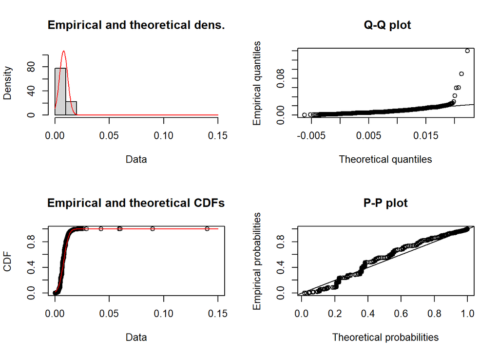

```
## summary statistics
## ------
## min:  0   max:  0.1504
## median:  0.0074
## mean:  0.008043383
## estimated sd:  0.003844971
## estimated skewness:  10.07275
## estimated kurtosis:  313.2705
```

```
## summary statistics
## ------
## min:  0   max:  0.1401097
## median:  0.007372754
## mean:  0.008004105
## estimated sd:  0.003747568
## estimated skewness:  8.98871
## estimated kurtosis:  262.7838
```

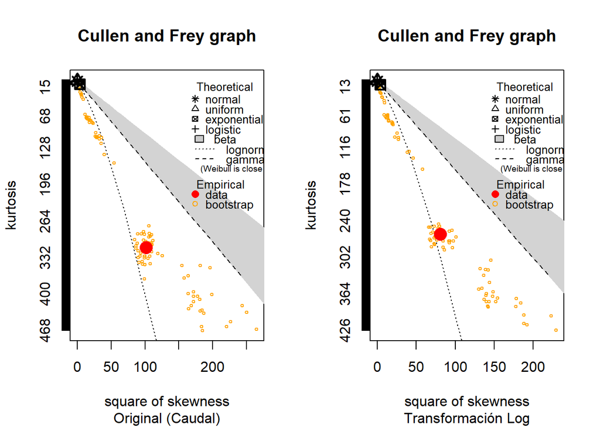

# *Distribución lognormal*

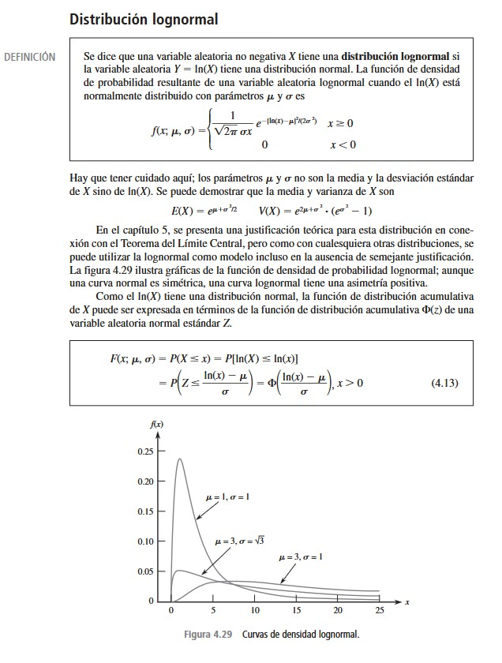

# *Tabla de entrada de datos*

```
## [1] 85
```

```
##     Min.  1st Qu.   Median     Mean  3rd Qu.     Max.
## 0.001600 0.005800 0.007400 0.008013 0.009900 0.019900
```

Se utilizó el método de muestreo por Hipercubo Latino debido a que la variable de rigor seleccionada (*Caudal*), presenta comportamiento continuo, alta dispersión y asimetría positiva. Este método permite garantizar una representación homogénea de toda la distribución de la variable, evitando la concentración excesiva de observaciones en rangos de alta densidad y mejorando la cobertura de valores extremos. En comparación con el muestreo aleatorio simple, el muestreo por Hipercubo Latino proporciona mayor eficiencia en la exploración del espacio muestral y una mejor representatividad estadística de la variabilidad del caudal.

# *Tablas de distribución de frecuencias variables cualitativas y cuantitativas + Gráficos*

Tabla de frecuencias de la variable Cuenca

| Cuenca | Frecuencia | hi.Freq | Porcentaje.Freq |
| --- | --- | --- | --- |
| DIRECTOS AL R. ABURRA ZU MEDELLIN (INTERCUENCA 5) | 1 | 0.012 | 1.18 |
| Directos al R. Cauca (md) entre Q. Tesorera y Q. La Clara | 1 | 0.012 | 1.18 |
| Directos R. Cauca (mi) - R. Aurra - NSS | 1 | 0.012 | 1.18 |
| Directos R. Cauca (mi) entre Q. Seca y Q. Tiembla | 1 | 0.012 | 1.18 |
| DIRECTOS RI. ABURRA (INTERCUENCA 2) | 4 | 0.047 | 4.71 |
| Q. Aguas Frías | 5 | 0.059 | 5.88 |
| Q. EL CHUSCAL | 2 | 0.024 | 2.35 |
| Q. El Guamo | 2 | 0.024 | 2.35 |
| Q. El Jobo y otros directos al Nechi (md) | 1 | 0.012 | 1.18 |
| Q. EL SALADO | 1 | 0.012 | 1.18 |
| Q. El Tigre | 1 | 0.012 | 1.18 |
| Q. Honda, Q Pena y otros directos al Cauca (mi) | 1 | 0.012 | 1.18 |
| Q. Horna | 1 | 0.012 | 1.18 |
| Q. La Clara | 2 | 0.024 | 2.35 |
| Q. LA GARCIA | 2 | 0.024 | 2.35 |
| Q. LA IGUANA | 7 | 0.082 | 8.24 |
| Q. La Jimenez | 1 | 0.012 | 1.18 |
| Q. La Peinada | 1 | 0.012 | 1.18 |
| Q. La Pretel | 6 | 0.071 | 7.06 |
| Q. La Sopetrana | 1 | 0.012 | 1.18 |
| Q. La Sucia | 3 | 0.035 | 3.53 |
| Q. Mulato | 2 | 0.024 | 2.35 |
| Q. OVEJAS | 6 | 0.071 | 7.06 |
| Q. PIEDRAS BLANCAS | 2 | 0.024 | 2.35 |
| Q. RODAS | 2 | 0.024 | 2.35 |
| Q. Sabaletas | 4 | 0.047 | 4.71 |
| Q. San Andrés | 1 | 0.012 | 1.18 |
| Q. Santa Barbara | 6 | 0.071 | 7.06 |
| Q. SANTA ELENA | 3 | 0.035 | 3.53 |
| Q. Santa Isabel | 1 | 0.012 | 1.18 |
| Q. Vequedo | 2 | 0.024 | 2.35 |
| R. Amagá | 2 | 0.024 | 2.35 |
| R. Guadalupe | 1 | 0.012 | 1.18 |
| R. Piedras | 2 | 0.024 | 2.35 |
| R. Porce | 3 | 0.035 | 3.53 |
| R. Tonusco | 1 | 0.012 | 1.18 |
| Rio Aburrá- NSS | 2 | 0.024 | 2.35 |

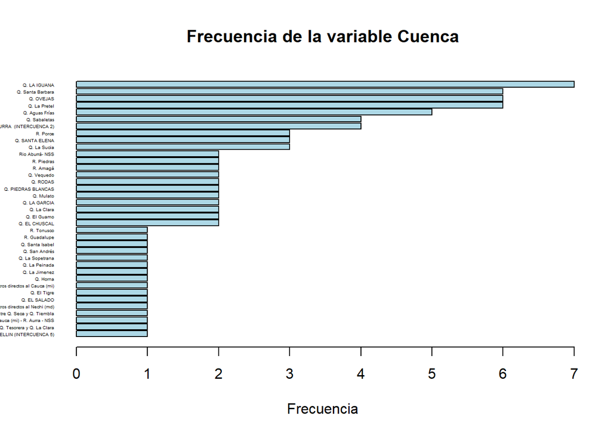

Tabla de frecuencias de la variable Manejo efluente

| Manejo_efluente | Frecuencia | hi.Freq | Porcentaje.Freq |
| --- | --- | --- | --- |
| Montículo | 1 | 0.012 | 1.18 |
| Pozo de absorción o infiltración | 35 | 0.412 | 41.18 |
| Zanja o Campo de infiltración | 49 | 0.576 | 57.65 |

Tabla de frecuencias de la variable Tratamiento Secundario

| Tratamiento_secundario | Frecuencia | hi.Freq | Porcentaje.Freq |
| --- | --- | --- | --- |
| Filtro anaerobio | 56 | 0.659 | 65.88 |
| Sedimentación | 1 | 0.012 | 1.18 |
| Tanque septico | 28 | 0.329 | 32.94 |

Tabla de frecuencias no agrupada - Permanentes

| Permanentes | Frecuencia | hi.Freq | Porcentaje |
| --- | --- | --- | --- |
| 0 | 1 | 0.012 | 1.18 |
| 1 | 4 | 0.047 | 4.71 |
| 2 | 7 | 0.082 | 8.24 |
| 3 | 29 | 0.341 | 34.12 |
| 4 | 25 | 0.294 | 29.41 |
| 5 | 9 | 0.106 | 10.59 |
| 6 | 4 | 0.047 | 4.71 |
| 7 | 3 | 0.035 | 3.53 |
| 8 | 2 | 0.024 | 2.35 |
| 10 | 1 | 0.012 | 1.18 |

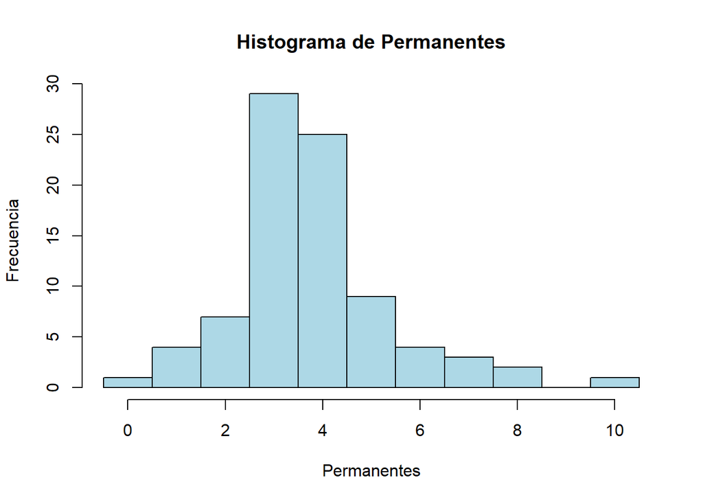

Tabla de frecuencias no agrupada - Transitorias

| Transitorias | Frecuencia | hi.Freq | Porcentaje |
| --- | --- | --- | --- |
| 0 | 37 | 0.435 | 43.53 |
| 1 | 9 | 0.106 | 10.59 |
| 2 | 13 | 0.153 | 15.29 |
| 3 | 7 | 0.082 | 8.24 |
| 4 | 3 | 0.035 | 3.53 |
| 5 | 5 | 0.059 | 5.88 |
| 6 | 8 | 0.094 | 9.41 |
| 7 | 1 | 0.012 | 1.18 |
| 10 | 2 | 0.024 | 2.35 |

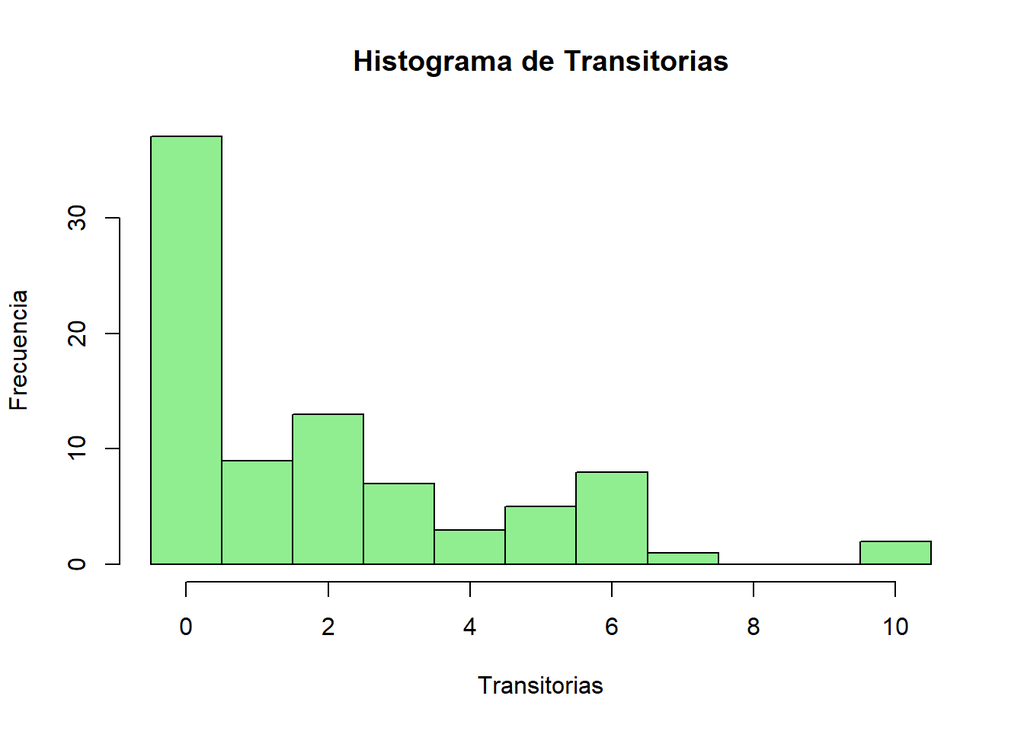

Tabla de frecuencia agrupada - Caudal

| Intervalo | Frecuencia | hi.Freq | Porcentaje |
| --- | --- | --- | --- |
| (0.00158,0.00389] | 5 | 0.059 | 5.88 |
| (0.00389,0.00617] | 19 | 0.224 | 22.35 |
| (0.00617,0.00846] | 27 | 0.318 | 31.76 |
| (0.00846,0.0108] | 20 | 0.235 | 23.53 |
| (0.0108,0.013] | 8 | 0.094 | 9.41 |
| (0.013,0.0153] | 4 | 0.047 | 4.71 |
| (0.0153,0.0176] | 1 | 0.012 | 1.18 |
| (0.0176,0.0199] | 1 | 0.012 | 1.18 |

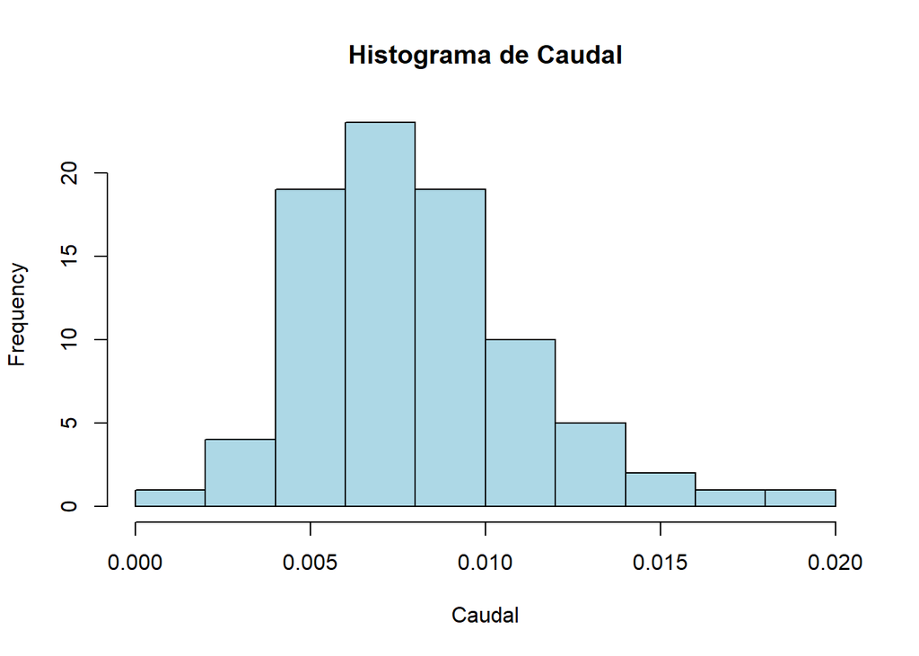

# *Medidas de Tendencia Central variables cuantitativas*

Medidas de tendencia central - Caudal

| Media | Mediana | Moda |
| --- | --- | --- |
| 0.0080129 | 0.0074 | 0.005 |

Medidas de tendencia central - Permanentes

| Media | Mediana | Moda |
| --- | --- | --- |
| 3.776471 | 4 | 3 |

Medidas de tendencia central - Transitorias

| Media | Mediana | Moda |
| --- | --- | --- |
| 1.976471 | 1 | 0 |

# *Análisis de simetría*

Coeficiente de asimetría - Caudal

| Asimetria |
| --- |
| 0.971 |

Coeficiente de asimetría - Permanentes

| Asimetria |
| --- |
| 0.987 |

Este coeficiente de asimetría indica que la mayoría de los domicilios poseen un número relativamente bajo de personas permanentes, mientras que un grupo reducido presenta cantidades significativamente mayores, desplazando la distribución hacia la derecha.

Coeficiente de asimetría - Transitorias

| Asimetria |
| --- |
| 1.277 |

Este coeficiente de asimetría sugiere que la mayoría de los domicilios registran pocas personas transitorias, mientras que algunos casos excepcionales presentan cantidades elevadas, generando una cola pronunciada hacia los valores altos.

En términos sociales/demográficos esto puede indicar:

- Cierta estabilidad en el número de habitantes permanentes pero mucha variabilidad en la población transitoria, posiblemente asociada a: actividades temporales, movilidad poblacional o usos ocasionales de los predios.

En cuanto a la relación de estas variables con la normalidad, estas se alejan de una simetría normal, especialmente la variable *Transitorias*, la media puede verse afectada por valores extremos, y la mediana puede representar mejor el comportamiento típico de los datos.

# *Análisis de Regla Empírica*

Regla empírica - Caudal

| Intervalo | Porcentaje |
| --- | --- |
| 1 Desv | 76.47 |
| 2 Desv | 96.47 |
| 3 Desv | 98.82 |

# *Medidas de Variación*

```
##   Rango Varianza Desviacion_Estandar Coeficiente_Variacion
## 1    10  2.67563            1.635735              43.31387
```

```
##   Rango Varianza Desviacion_Estandar Coeficiente_Variacion
## 1    10  5.97563             2.44451              123.6806
```

```
##    Rango   Varianza Desviacion_Estandar Coeficiente_Variacion
## 1 0.0183 1.0294e-05         0.003208426              40.04055
```

Las medidas de variación evidencian que las tres variables cuantitativas presentan dispersión significativa. La variable *Transitorias* mostró la mayor heterogeneidad, con un coeficiente de variación superior al 100%, indicando alta dispersión relativa y presencia de valores extremos. Por su parte, las variables *Permanentes* y *Caudal* presentaron variabilidad moderada-alta, reflejando diferencias importantes entre los registros analizados.

# *Cruce de variables Cualitativas*

Tabla de contingencia: Cuenca vs Tratamiento Secundario

|  | Filtro anaerobio | Sedimentación | Tanque septico |
| --- | --- | --- | --- |
| DIRECTOS AL R. ABURRA ZU MEDELLIN (INTERCUENCA 5) | 1 | 0 | 0 |
| Directos al R. Cauca (md) entre Q. Tesorera y Q. La Clara | 1 | 0 | 0 |
| Directos R. Cauca (mi) - R. Aurra - NSS | 1 | 0 | 0 |
| Directos R. Cauca (mi) entre Q. Seca y Q. Tiembla | 1 | 0 | 0 |
| DIRECTOS RI. ABURRA (INTERCUENCA 2) | 4 | 0 | 0 |
| Q. Aguas Frías | 3 | 0 | 2 |
| Q. EL CHUSCAL | 2 | 0 | 0 |
| Q. El Guamo | 2 | 0 | 0 |
| Q. El Jobo y otros directos al Nechi (md) | 1 | 0 | 0 |
| Q. EL SALADO | 1 | 0 | 0 |
| Q. El Tigre | 1 | 0 | 0 |
| Q. Honda, Q Pena y otros directos al Cauca (mi) | 0 | 0 | 1 |
| Q. Horna | 0 | 0 | 1 |
| Q. La Clara | 2 | 0 | 0 |
| Q. LA GARCIA | 2 | 0 | 0 |
| Q. LA IGUANA | 7 | 0 | 0 |
| Q. La Jimenez | 1 | 0 | 0 |
| Q. La Peinada | 0 | 0 | 1 |
| Q. La Pretel | 6 | 0 | 0 |
| Q. La Sopetrana | 1 | 0 | 0 |
| Q. La Sucia | 3 | 0 | 0 |
| Q. Mulato | 2 | 0 | 0 |
| Q. OVEJAS | 0 | 0 | 6 |
| Q. PIEDRAS BLANCAS | 1 | 0 | 1 |
| Q. RODAS | 2 | 0 | 0 |
| Q. Sabaletas | 0 | 0 | 4 |
| Q. San Andrés | 0 | 0 | 1 |
| Q. Santa Barbara | 0 | 0 | 6 |
| Q. SANTA ELENA | 3 | 0 | 0 |
| Q. Santa Isabel | 1 | 0 | 0 |
| Q. Vequedo | 0 | 0 | 2 |
| R. Amagá | 2 | 0 | 0 |
| R. Guadalupe | 0 | 1 | 0 |
| R. Piedras | 1 | 0 | 1 |
| R. Porce | 2 | 0 | 1 |
| R. Tonusco | 0 | 0 | 1 |
| Rio Aburrá- NSS | 2 | 0 | 0 |

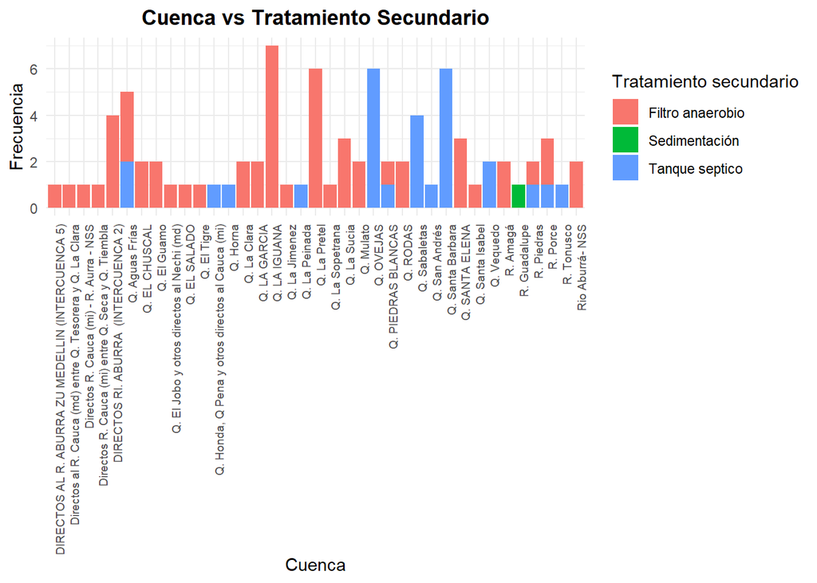

Se observa una mayor presencia de filtros anaerobios en cuencas vinculadas al sistema hídrico del río Medellín-Aburrá, lo cual podría estar relacionado con mayores requerimientos de tratamiento de aguas residuales en áreas urbanas y periurbanas. Esta tendencia sugiere una posible influencia de factores como densidad poblacional, presión ambiental y control institucional sobre la selección de tecnologías de tratamiento utilizadas en los vertimientos al suelo.

Tabla de contingencia: Cuenca vs Manejo Efluente

|  | Montículo | Pozo de absorción o infiltración | Zanja o Campo de infiltración |
| --- | --- | --- | --- |
| DIRECTOS AL R. ABURRA ZU MEDELLIN (INTERCUENCA 5) | 0 | 1 | 0 |
| Directos al R. Cauca (md) entre Q. Tesorera y Q. La Clara | 0 | 0 | 1 |
| Directos R. Cauca (mi) - R. Aurra - NSS | 0 | 0 | 1 |
| Directos R. Cauca (mi) entre Q. Seca y Q. Tiembla | 0 | 0 | 1 |
| DIRECTOS RI. ABURRA (INTERCUENCA 2) | 0 | 2 | 2 |
| Q. Aguas Frías | 0 | 2 | 3 |
| Q. EL CHUSCAL | 0 | 0 | 2 |
| Q. El Guamo | 0 | 0 | 2 |
| Q. El Jobo y otros directos al Nechi (md) | 0 | 1 | 0 |
| Q. EL SALADO | 0 | 0 | 1 |
| Q. El Tigre | 0 | 0 | 1 |
| Q. Honda, Q Pena y otros directos al Cauca (mi) | 0 | 0 | 1 |
| Q. Horna | 0 | 1 | 0 |
| Q. La Clara | 0 | 2 | 0 |
| Q. LA GARCIA | 0 | 0 | 2 |
| Q. LA IGUANA | 0 | 0 | 7 |
| Q. La Jimenez | 0 | 0 | 1 |
| Q. La Peinada | 0 | 0 | 1 |
| Q. La Pretel | 0 | 6 | 0 |
| Q. La Sopetrana | 0 | 0 | 1 |
| Q. La Sucia | 0 | 2 | 1 |
| Q. Mulato | 0 | 2 | 0 |
| Q. OVEJAS | 0 | 5 | 1 |
| Q. PIEDRAS BLANCAS | 0 | 2 | 0 |
| Q. RODAS | 0 | 2 | 0 |
| Q. Sabaletas | 0 | 0 | 4 |
| Q. San Andrés | 0 | 1 | 0 |
| Q. Santa Barbara | 0 | 0 | 6 |
| Q. SANTA ELENA | 0 | 1 | 2 |
| Q. Santa Isabel | 0 | 1 | 0 |
| Q. Vequedo | 0 | 0 | 2 |
| R. Amagá | 0 | 2 | 0 |
| R. Guadalupe | 1 | 0 | 0 |
| R. Piedras | 0 | 0 | 2 |
| R. Porce | 0 | 2 | 1 |
| R. Tonusco | 0 | 0 | 1 |
| Rio Aburrá- NSS | 0 | 0 | 2 |

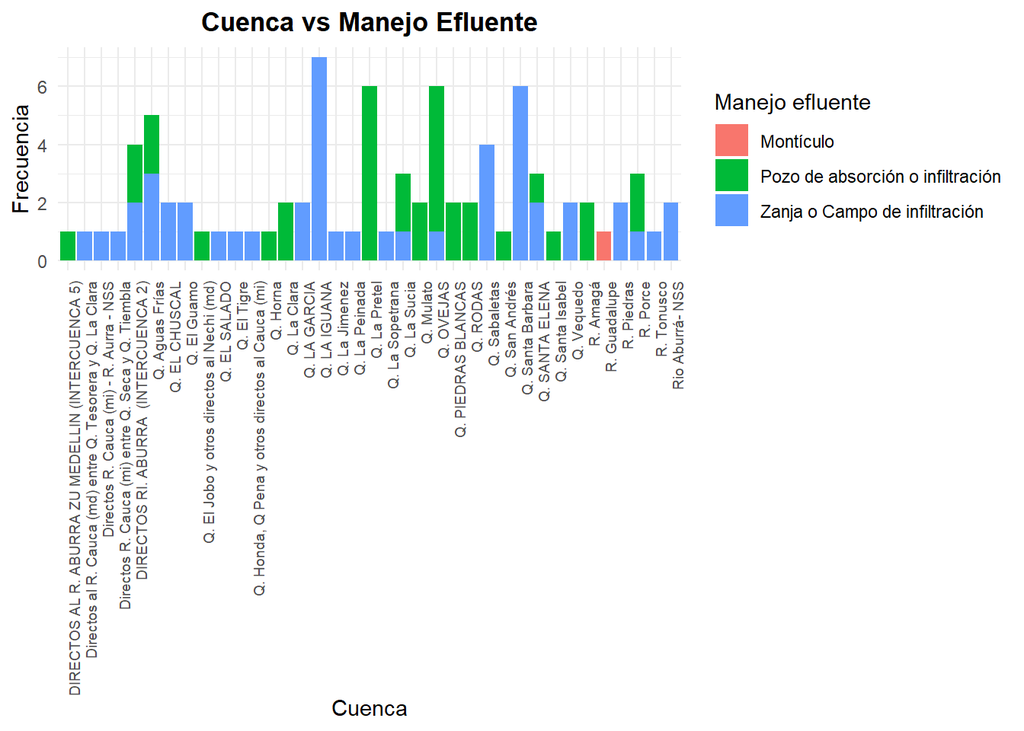

El sistema más común de disposición final del Efluente es la infiltración al suelo, probablemente porque es más práctico y económico en zonas rurales o periurbanas. Las cuencas donde predominan los pozos de absorción como sistema de disposición final del Efluente posiblemente presentan condiciones de suelo favorables para la infiltración vertical, menor disponibilidad de espacio superficial o sistemas individuales más simples. Por último, se evidencia que el sistema tipo Montículo es muy poco frecuente, esto se debe a que suele utilizarse cuando el suelo no infiltra bien. En cuencas asociadas al sistema hídrico Medellín-Aburrá se observa una mayor presencia de sistemas de infiltración controlada, lo que podría estar relacionado con mayores requerimientos ambientales y condiciones de urbanización en dichas zonas.

# *Modelamiento de la variable cuantitativa*

[output not shown]

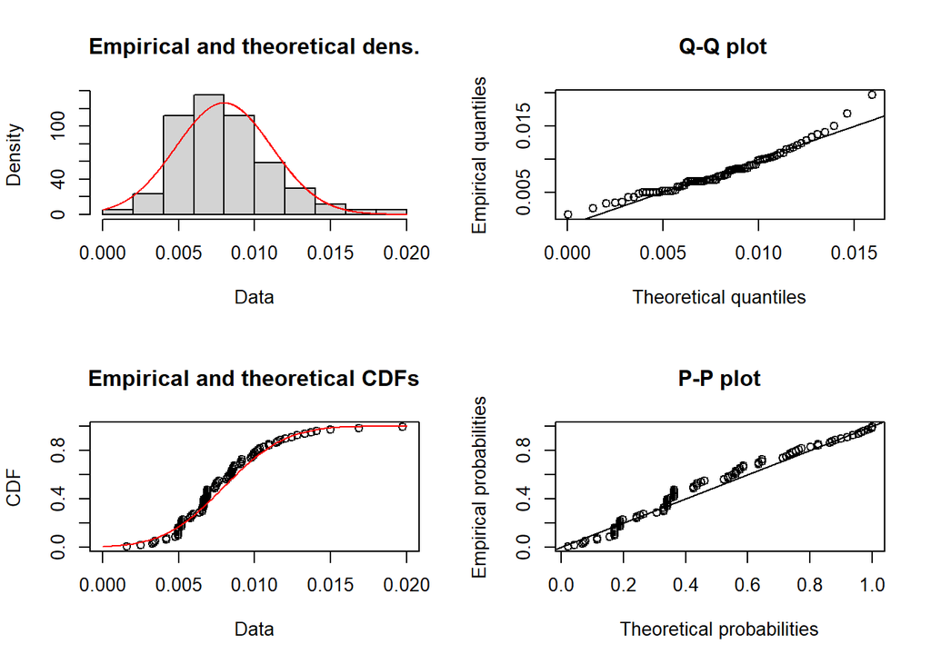

# *Dependencia entre variables cualitativas*

## **Hipótesis**

### **Hipótesis nula**

```
            H0: Las variables son independientes
```

#### **Hipótesis alternativa**

```
            H1: Existe dependencia entre las variables
```

```
##
##                                                             Filtro anaerobio
##   DIRECTOS AL R. ABURRA ZU MEDELLIN (INTERCUENCA 5)                        1
##   Directos al R. Cauca (md) entre Q. Tesorera y Q. La Clara                1
##   Directos R. Cauca (mi) - R. Aurra - NSS                                  1
##   Directos R. Cauca (mi) entre Q. Seca y Q. Tiembla                        1
##   DIRECTOS RI. ABURRA  (INTERCUENCA 2)                                     4
##   Q. Aguas Frías                                                           3
##   Q. EL CHUSCAL                                                            2
##   Q. El Guamo                                                              2
##   Q. El Jobo y otros directos al Nechi (md)                                1
##   Q. EL SALADO                                                             1
##   Q. El Tigre                                                              1
##   Q. Honda, Q Pena y otros directos al Cauca (mi)                          0
##   Q. Horna                                                                 0
##   Q. La Clara                                                              2
##   Q. LA GARCIA                                                             2
##   Q. LA IGUANA                                                             7
##   Q. La Jimenez                                                            1
##   Q. La Peinada                                                            0
##   Q. La Pretel                                                             6
##   Q. La Sopetrana                                                          1
##   Q. La Sucia                                                              3
##   Q. Mulato                                                                2
##   Q. OVEJAS                                                                0
##   Q. PIEDRAS BLANCAS                                                       1
##   Q. RODAS                                                                 2
##   Q. Sabaletas                                                             0
##   Q. San Andrés                                                            0
##   Q. Santa Barbara                                                         0
##   Q. SANTA ELENA                                                           3
##   Q. Santa Isabel                                                          1
##   Q. Vequedo                                                               0
##   R. Amagá                                                                 2
##   R. Guadalupe                                                             0
##   R. Piedras                                                               1
##   R. Porce                                                                 2
##   R. Tonusco                                                               0
##   Rio Aburrá- NSS                                                          2
##
```

[output cut: 62 more lines]

```
##   Q. OVEJAS                                                              6
##   Q. PIEDRAS BLANCAS                                                     1
##   Q. RODAS                                                               0
##   Q. Sabaletas                                                           4
##   Q. San Andrés                                                          1
##   Q. Santa Barbara                                                       6
##   Q. SANTA ELENA                                                         0
##   Q. Santa Isabel                                                        0
##   Q. Vequedo                                                             2
##   R. Amagá                                                               0
##   R. Guadalupe                                                           0
##   R. Piedras                                                             1
##   R. Porce                                                               1
##   R. Tonusco                                                             1
##   Rio Aburrá- NSS                                                        0
```

```
##
##  Pearson's Chi-squared test
##
## data:  tabla_cont
## X-squared = 156.95, df = 72, p-value = 2.949e-08
```

Se aplicó una prueba Chi-cuadrado de independencia entre las variables *Cuenca* y *Tratamiento secundario*. Los resultados permitieron evaluar si la selección del sistema de tratamiento depende de la cuenca hidrográfica asociada al vertimiento. Dado que el valor-p es menor que 0.05, se rechaza la hipótesis nula de independencia, concluyendo que existe una relación estadísticamente significativa entre la cuenca hidrográfica y el tipo de tratamiento secundario implementado en los vertimientos analizados. Debido al alto número de categorías y algunas frecuencias pequeñas, los resultados deben interpretarse con precaución, aunque la evidencia estadística sugiere una asociación clara entre las variables.